# Biostat/Biomath M257 Homework 1

Due Apr 14 @ 11:59PM

Author

Zian ZHUANG (UID:405444165)

Published

April 14, 2023

```julia
versioninfo()
```

```
Julia Version 1.8.5
Commit 17cfb8e65e (2023-01-08 06:45 UTC)
Platform Info:
  OS: Windows (x86_64-w64-mingw32)
  CPU: 16 × AMD Ryzen 7 5800 8-Core Processor
  WORD_SIZE: 64
  LIBM: libopenlibm
  LLVM: libLLVM-13.0.1 (ORCJIT, znver3)
  Threads: 16 on 16 virtual cores
Environment:
  JULIA_NUM_THREADS = 16
```

```julia
using Pkg
Pkg.activate(pwd())
Pkg.instantiate()
Pkg.status()
using LoopVectorization, Random, CairoMakie, LinearAlgebra, BenchmarkTools
```

```
  Activating project at `C:\Users\larry\Dropbox\zza\UCLA\academic\year 3\quarter 3\257\biostat-257-2023-spring\hw1`
```

```
Status `C:\Users\larry\Dropbox\zza\UCLA\academic\year 3\quarter 3\257\biostat-257-2023-spring\hw1\Project.toml`
  [6e4b80f9] BenchmarkTools v1.3.2
  [13f3f980] CairoMakie v0.10.4
  [e9467ef8] GLMakie v0.8.4
  [bdcacae8] LoopVectorization v0.12.157
  [ee78f7c6] Makie v0.19.4
  [37e2e46d] LinearAlgebra
  [9a3f8284] Random
```

## 1 Q1

**No handwritten homework reports are accepted for this course.** We work with Git/GitHub. Efficient and abundant use of Git, e.g., **frequent and well-documented** commits, is an important criterion for grading your homework.

1. If you don’t have a GitHub account, apply for the [Student Developer Pack](https://education.github.com/pack) at GitHub using your UCLA email.
2. Create a **private** repository `biostat-257-2023-spring` and add `Hua-Zhou` and `parsajamshidian` (TA) as your collaborators.
3. Top directories of the repository should be `hw1`, `hw2`, … You may create other branches for developing your homework solutions; but the `master` branch will be your presentation area. Put your homework submission files (Jupyter notebook `.ipynb`, html converted from notebook, all code and data set to reproduce results) in the `master` branch.
4. After each homework due date, teaching assistant and instructor will check out your `master` branch for grading. Tag each of your homework submissions with tag names `hw1`, `hw2`, … Tagging time will be used as your submission time. That means if you tag your hw1 submission after deadline, penalty points will be deducted for late submission.
5. Read the [style guide](https://github.com/invenia/BlueStyle) for Julia programming. Following rules in the style guide will be strictly enforced when grading: (1) four space indenting rule, (2) 92 charcter rule, (3) space after comma rule, (4) no space before comma rule, (5) space around binary operator rule.

### 1.1 Sol.

1. done
2. done
3. done
4. done
5. done

## 2 Q2

Let’s check whether floating-point numbers obey certain algebraic rules. For 2-5, one counter-example suffices.

1. Associative rule for addition says `(x + y) + z == x + (y + z)`. Check association rule using `x = 0.1`, `y = 0.1` and `z = 1.0` in Julia. Explain what you find.
2. Do floating-point numbers obey the associative rule for multiplication: `(x * y) * z == x * (y * z)`?
3. Do floating-point numbers obey the distributive rule: `a * (x + y) == a * x + a * y`?
4. Is `0 * x == 0` true for all floating-point number `x`?
5. Is `x / a == x * (1 / a)` always true?

### 2.1 1.

```julia
x, y, z = 0.1, 0.1, 1.0
print("(x + y) + z = ", (x + y) + z, ";  x + (y + z) = ", x + (y + z))
(x + y) + z == x + (y + z)
```

```
(x + y) + z = 1.2;  x + (y + z) = 1.2000000000000002
```

```
false
```

We found that associative rule is invalid here. Explain: When we added two floating-point numbers with different magnitudes, computer did rounding and we loose the precision of the number with smaller magnitude. In `(x + y) + z` we rounded one time but `x + (y + z)` we did twice. Thus, they provided different answers.

### 2.2 2.

```julia
x, y, z = 11.1, 0.1, 111.1
print("(x * y) * z = ", (x * y) * z, ";  x * (y * z) = ", x * (y * z))
(x * y) * z == x * (y * z)
```

```
(x * y) * z = 123.321;  x * (y * z) = 123.32099999999998
```

```
false
```

No, floating-point numbers do not obey the associative rule for multiplication. The reason is same as above (rounding issues).

### 2.3 3.

```julia
x, y, z = 11.1, 0.1, 111.1
print("z * (x + y) = ", z * (x + y), ";  z * x + z * y = ", z * x + z * y)
(x * y) * z == x * (y * z)
```

```
z * (x + y) = 1244.32;  z * x + z * y = 1244.3199999999997
```

```
false
```

No, floating-point numbers do not obey the distributive rule. The reason is same as above (rounding issues).

### 2.4 4.

```julia
0 * Inf == 0
```

```
false
```

We can see `0 * x == 0` is not always true for all floating-point number `x`.

### 2.5 5.

```julia
x, a = 1e-13, 1e10
print("x / a = ", x / a, ";  x * (1 / a) = ", x * (1 / a))
x / a == x * (1 / a)
```

```
x / a = 1.0e-23;  x * (1 / a) = 1.0000000000000001e-23
```

```
false
```

Then we can see `x / a == x * (1 / a)` is not always true.

## 3 Q3

Consider Julia function

```julia
function g(k)
    for i in 1:10
        k = 5k - 1
    end
    k
end
```

```
g (generic function with 1 method)
```

1. Use `@code_llvm` to find the LLVM bitcode of compiled `g` with `Int64` input.
2. Use `@code_llvm` to find the LLVM bitcode of compiled `g` with `Float64` input.
3. Compare the bitcode from questions 1 and 2. What do you find?
4. Read Julia documentation on `@fastmath` and repeat the questions 1-3 on the function

```julia
function g_fastmath(k)
    @fastmath for i in 1:10
        k = 5k - 1
    end
    k
end
```

```
g_fastmath (generic function with 1 method)
```

Explain what does the macro `@fastmath` do? And why are the bitcodes for `g` and `g_fastmath` with `Float64` input different? (Hint: Q2)

### 3.1 1.

```julia
@code_llvm g(1)
```

```
;  @ In[9]:1 within `g`
; Function Attrs: uwtable
define i64 @julia_g_2525(i64 signext %0) #0 {
top:
;  @ In[9]:3 within `g`
; ┌ @ int.jl:88 within `*`
   %1 = mul i64 %0, 9765625
; └
; ┌ @ int.jl:86 within `-`
   %2 = add i64 %1, -2441406
; └
;  @ In[9]:5 within `g`
  ret i64 %2
}
```

### 3.2 2.

```julia
@code_llvm g(1.1)
```

```
;  @ In[9]:1 within `g`
; Function Attrs: uwtable
define double @julia_g_2548(double %0) #0 {
top:
;  @ In[9]:3 within `g`
; ┌ @ promotion.jl:389 within `*` @ float.jl:385
   %1 = fmul double %0, 5.000000e+00
; └
; ┌ @ promotion.jl:390 within `-` @ float.jl:384
   %2 = fadd double %1, -1.000000e+00
; └
; ┌ @ promotion.jl:389 within `*` @ float.jl:385
   %3 = fmul double %2, 5.000000e+00
; └
; ┌ @ promotion.jl:390 within `-` @ float.jl:384
   %4 = fadd double %3, -1.000000e+00
; └
; ┌ @ promotion.jl:389 within `*` @ float.jl:385
   %5 = fmul double %4, 5.000000e+00
; └
; ┌ @ promotion.jl:390 within `-` @ float.jl:384
   %6 = fadd double %5, -1.000000e+00
; └
; ┌ @ promotion.jl:389 within `*` @ float.jl:385
   %7 = fmul double %6, 5.000000e+00
; └
; ┌ @ promotion.jl:390 within `-` @ float.jl:384
   %8 = fadd double %7, -1.000000e+00
; └
; ┌ @ promotion.jl:389 within `*` @ float.jl:385
   %9 = fmul double %8, 5.000000e+00
; └
; ┌ @ promotion.jl:390 within `-` @ float.jl:384
   %10 = fadd double %9, -1.000000e+00
; └
; ┌ @ promotion.jl:389 within `*` @ float.jl:385
   %11 = fmul double %10, 5.000000e+00
; └
; ┌ @ promotion.jl:390 within `-` @ float.jl:384
   %12 = fadd double %11, -1.000000e+00
```

[output cut: 13 more lines]

```
; ┌ @ promotion.jl:389 within `*` @ float.jl:385
   %17 = fmul double %16, 5.000000e+00
; └
; ┌ @ promotion.jl:390 within `-` @ float.jl:384
   %18 = fadd double %17, -1.000000e+00
; └
; ┌ @ promotion.jl:389 within `*` @ float.jl:385
   %19 = fmul double %18, 5.000000e+00
; └
; ┌ @ promotion.jl:390 within `-` @ float.jl:384
   %20 = fadd double %19, -1.000000e+00
; └
;  @ In[9]:5 within `g`
  ret double %20
}
```

### 3.3 3.

We can see that although we didn’t specify a type annotation. LLVM bitcodes were still generated depending on the appropriate argument type. LLVM code shows that , compared to the Float type (20 steps), computation for Int type is much simpler (2 steps).

### 3.4 4.

```julia
@code_llvm g_fastmath(1)
```

```
;  @ In[10]:1 within `g_fastmath`
; Function Attrs: uwtable
define i64 @julia_g_fastmath_2550(i64 signext %0) #0 {
top:
;  @ In[10]:3 within `g_fastmath`
; ┌ @ fastmath.jl:270 within `mul_fast`
; │┌ @ int.jl:88 within `*`
    %1 = mul i64 %0, 9765625
; └└
; ┌ @ fastmath.jl:270 within `sub_fast`
; │┌ @ int.jl:86 within `-`
    %2 = add i64 %1, -2441406
; └└
;  @ In[10]:5 within `g_fastmath`
  ret i64 %2
}
```

```julia
@code_llvm g_fastmath(1.1)
```

```
;  @ In[10]:1 within `g_fastmath`
; Function Attrs: uwtable
define double @julia_g_fastmath_2552(double %0) #0 {
top:
;  @ In[10]:3 within `g_fastmath`
; ┌ @ fastmath.jl:267 within `mul_fast` @ fastmath.jl:167
   %1 = fmul fast double %0, 0x4162A05F20000000
; └
; ┌ @ fastmath.jl:267 within `sub_fast` @ fastmath.jl:166
   %2 = fadd fast double %1, 0xC142A05F00000000
; └
;  @ In[10]:5 within `g_fastmath`
  ret double %2
}
```

As we can tell from the llvm code, `fastmath` deals with the Float types in a more efficient way (2 steps) than the original method (20 steps). From the document we see that `fastmath` method

> Execute a transformed version of the expression, which calls functions that may violate strict IEEE semantics. This allows the fastest possible operation, but results are undefined – be careful when doing this, as it may change numerical results.

Then we know that the method has shorter bitcodes because it executed a transformed version of the expression. In addition, We need to be careful when using this tool, since it violate strict IEEE semantics.

## 4 Q4

Create the vector `x = (0.988, 0.989, 0.990, ..., 1.010, 1.011, 1.012)`.

1. Plot the polynomial `y = x^7 - 7x^6 + 21x^5 - 35x^4 + 35x^3 - 21x^2 + 7x - 1` at points `x`.
2. Plot the polynomial `y = (x - 1)^7` at points `x`.
3. Explain what you found.

### 4.1 1.

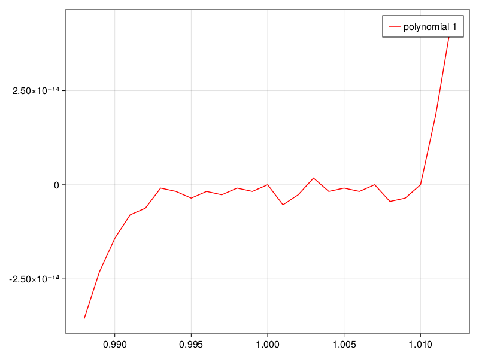

```julia
x = [0.988:0.001:1.012...]
function f1(x::Real)
    x^7 - 7x^6 + 21x^5 - 35x^4 + 35x^3 - 21x^2 + 7x - 1
end

lines(x, f1, color = :red, label = "polynomial 1")
axislegend()
current_figure()
```

### 4.2 2.

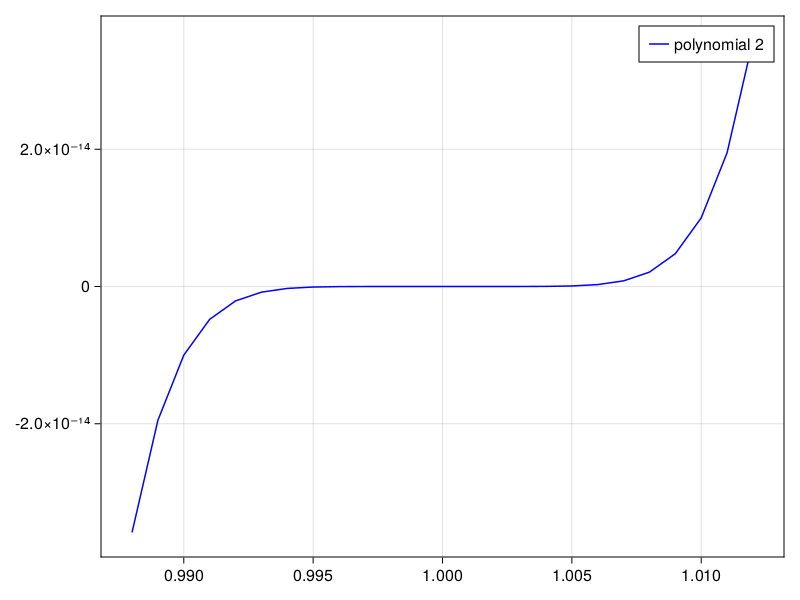

```julia
x = [0.988:0.001:1.012...]
function f2(x :: Real)
    (x - 1)^7
end
lines(x, f2, color = :blue, label = "polynomial 2")
axislegend()
current_figure()
```

### 4.3 3.

Here we plot `y = x^7 - 7x^6 + 21x^5 - 35x^4 + 35x^3 - 21x^2 + 7x - 1` and `y = (x - 1)^7` together:

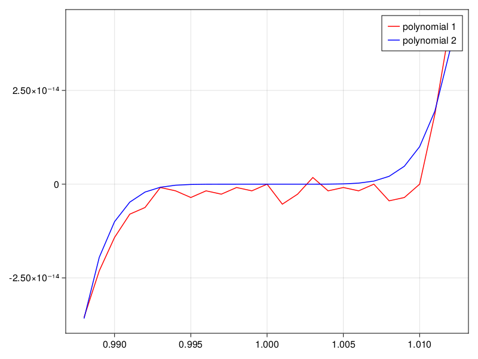

```julia
lines(x, f1, color = :red, label = "polynomial 1")
lines!(x, f2, color = :blue, label = "polynomial 2")
axislegend()
current_figure()
```

We can find that `y = (x - 1)^7` is smoother than `y = x^7 - 7x^6 + 21x^5 - 35x^4 + 35x^3 - 21x^2 + 7x - 1`. Possible reason: `y = x^7 - 7x^6 + 21x^5 - 35x^4 + 35x^3 - 21x^2 + 7x - 1` did much more rounding than `y = (x - 1)^7` because it calculated each block separately (`x^7`, `7x^6`, …) and lost more precision.

## 5 Q5

1. Show the **Sherman-Morrison formula**
   $$(\mathbf{A} + \mathbf{u} \mathbf{u}^T)^{-1} = \mathbf{A}^{-1} - \frac{1}{1 + \mathbf{u}^T \mathbf{A}^{-1} \mathbf{u}} \mathbf{A}^{-1} \mathbf{u} \mathbf{u}^T \mathbf{A}^{-1},$$
   where $\mathbf{A} \in \mathbb{R}^{n \times n}$ is nonsingular and $\mathbf{u} \in \mathbb{R}^n$. This formula supplies the inverse of the symmetric, rank-one perturbation of $\mathbf{A}$.
2. Show the **Woodbury formula**
   $$(\mathbf{A} + \mathbf{U} \mathbf{V}^T)^{-1} = \mathbf{A}^{-1} - \mathbf{A}^{-1} \mathbf{U} (\mathbf{I}_m + \mathbf{V}^T \mathbf{A}^{-1} \mathbf{U})^{-1} \mathbf{V}^T \mathbf{A}^{-1},$$
   where $\mathbf{A} \in \mathbb{R}^{n \times n}$ is nonsingular, $\mathbf{U}, \mathbf{V} \in \mathbb{R}^{n \times m}$, and $\mathbf{I}_m$ is the $m \times m$ identity matrix. In many applications $m$ is much smaller than $n$. Woodbury formula generalizes Sherman-Morrison and is valuable because the smaller matrix $\mathbf{I}_m + \mathbf{V}^T \mathbf{A}^{-1} \mathbf{U}$ is cheaper to invert than the larger matrix $\mathbf{A} + \mathbf{U} \mathbf{V}^T$.
3. Show the **binomial inversion formula**
   $$(\mathbf{A} + \mathbf{U} \mathbf{B} \mathbf{V}^T)^{-1} = \mathbf{A}^{-1} - \mathbf{A}^{-1} \mathbf{U} (\mathbf{B}^{-1} + \mathbf{V}^T \mathbf{A}^{-1} \mathbf{U})^{-1} \mathbf{V}^T \mathbf{A}^{-1},$$
   where $\mathbf{A}$ and $\mathbf{B}$ are nonsingular.
4. Show the identity
   $$\text{det}(\mathbf{A} + \mathbf{U} \mathbf{V}^T) = \text{det}(\mathbf{A}) \text{det}(\mathbf{I}_m + \mathbf{V}^T \mathbf{A}^{-1} \mathbf{U}).$$
   This formula is useful for evaluating the density of a multivariate normal with covariance matrix $\mathbf{A} + \mathbf{U} \mathbf{V}^T$.

**Hint**: 1 and 2 are special cases of 3. For 4, show that
$$\begin{pmatrix}
- \mathbf{A} & \mathbf{O} \\
\mathbf{O} & \mathbf{I} + \mathbf{V}^T \mathbf{A}^{-1} \mathbf{U}
\end{pmatrix} = \begin{pmatrix}
\mathbf{I} & \mathbf{O} \\
\mathbf{V}^T \mathbf{A}^{-1} & \mathbf{I}
\end{pmatrix} \begin{pmatrix}
- \mathbf{A} & \mathbf{U} \\
\mathbf{V}^T & \mathbf{I}
\end{pmatrix} \begin{pmatrix}
\mathbf{I} & \mathbf{A}^{-1} \mathbf{U} \\
\mathbf{O} & \mathbf{I}
\end{pmatrix}.$$

### 5.1 3.

Proof:

Firstly, we can

$$\begin{aligned}
& \left(A+U B V^{\top}\right)\left(A^{-1}-A^{-1} U\left(B^{-1}+V^{\top} A^{-1} U\right)^{-1} V^{\top} A^{-1}\right) \\
= & I+U B V^{\top} A^{-1}-U\left(B^{-1}+V^{\top} A^{-1} U\right)^{-1} V^{\top} A^{-1}-U B V^{\top} A^{-1} U\left(B^{-1}+V^{\top} A^{-1} U\right)^{-1} V^{\top} A^{-1} \\
= & I+U B V^{\top} A^{-1}-\left(U+U B V^{\top} A^{-1} U\right)\left(B^{-1}+V^{\top} A^{-1} U\right)^{-1} V^{\top} A^{-1} \\
= & I+U B V^{\top} A^{-1}-U B\left(B^{-1}+V^{\top} A^{-1} U\right)\left(B^{-1}+V^{\top} A^{-1} U\right)^{-1} V^{\top} A^{-1} \\
= & I+U B V^{\top} A^{-1}-U B V^{\top} A^{-1} \\
= & I
\end{aligned}$$

Since $\left(A+U B V^{\top}\right)^{-1}$ exist, we have,

$$\begin{aligned}
\left(A+U B V^{\top}\right)^{-1} I & =(A+U B V)^{-1}\left(A+U B U^{\top}\right)\left(A^{-1}-A^{-1} U\left(B^{-1}+U^{\top} A^{-1} U\right)^{-1} U^{\top} A^{-1}\right) \\
\left(A+U B V^{\top}\right)^{-1} & \left.=A^{-1}-A^{-1} U\left(B^{-1}+V^{\top} A^{\top} U\right)^{-1} V^{\top} A^{-1}\right.
\end{aligned}$$

### 5.2 1.

Based on what we derived in Q3, we set $\mathbf{u}=U, \mathbf{u}^{T}=V$ and $\mathbf{I}_1=B$, then we can get,

$$(\mathbf{A} + \mathbf{u} \mathbf{u}^T)^{-1} = \mathbf{A}^{-1} - \frac{1}{1 + \mathbf{u}^T \mathbf{A}^{-1} \mathbf{u}} \mathbf{A}^{-1} \mathbf{u} \mathbf{u}^T \mathbf{A}^{-1},$$

where $\mathbf{A} \in \mathbb{R}^{n \times n}$ is nonsingular and $\mathbf{u} \in \mathbb{R}^n$. This formula supplies the inverse of the symmetric, rank-one perturbation of $\mathbf{A}$.

### 5.3 2.

Based on what we derived in Q3, we set $\mathbf{I}_m=B$, then we can get,

$$(\mathbf{A} + \mathbf{U} \mathbf{V}^T)^{-1} = \mathbf{A}^{-1} - \mathbf{A}^{-1} \mathbf{U} (\mathbf{I}_m + \mathbf{V}^T \mathbf{A}^{-1} \mathbf{U})^{-1} \mathbf{V}^T \mathbf{A}^{-1},$$

where $\mathbf{A} \in \mathbb{R}^{n \times n}$ is nonsingular, $\mathbf{U}, \mathbf{V} \in \mathbb{R}^{n \times m}$, and $\mathbf{I}_m$ is the $m \times m$ identity matrix.

### 5.4 4.

Firstly, we can derive the relationship,
$$\begin{aligned}
& \left(\begin{array}{cc}
I & 0 \\
V^{\top} A^{-1} & I
\end{array}\right)\left(\begin{array}{cc}
-A & U \\
V^{\top} & I
\end{array}\right)\left(\begin{array}{cc}
I & A^{-1} U \\
0 & I
\end{array}\right) \\
=& \left(\begin{array}{cc}
-A& U \\
-V^{-} A^{-1} A+V^{\top} &V^{\top} A^{-1} U+I\end{array}\right)\left(\begin{array}{cc}
I & A^{-1} U \\
0 & I
\end{array}\right) \\
=& \left(\begin{array}{cc}
-A & U \\
0 & V^{\top} A^{-1} U+I
\end{array}\right)\left(\begin{array}{cc}
I & A^{-1} U \\
0 & I
\end{array}\right) \\
=& \left(\begin{array}{cc}
-A & -A A^{-1} U+U \\
0 & V^{\top} A^{-1} U+I
\end{array}\right) \\
=&\left(\begin{array}{cc}
-A & 0 \\
0 & I+V^{\top} A^{-1} U
\end{array}\right)
\end{aligned}$$

Then we know

$$\begin{aligned}
\operatorname{det}\left(\begin{array}{cc}
-A & 0 \\
0 & I+V^{\top} A^{-1} U
\end{array}\right)&=\operatorname{det}\left(\begin{array}{cc}
I & 0 \\
V^{\top} A^{-1} & I
\end{array}\right)\left(\begin{array}{cc}
-A & U \\
V^{\top} & I
\end{array}\right)\left(\begin{array}{cc}
I & A^{-1} U \\
0 & I
\end{array}\right) \\
\operatorname{det}(-A) \operatorname{det}\left(I+V^{\top} A^{-1} U\right)&= 1 * \operatorname{det}\left(\begin{array}{cc}
-A & U \\
V^{\top} & I
\end{array}\right)* 1 \\
\operatorname{det}\left(A+U V^{\top}\right)&=\operatorname{det}(A) \operatorname{det}\left(I+V^{\top} A^{-1} U\right)
\end{aligned}$$

## 6 Q6

Demonstrate the following facts about triangular and orthogonal matrices in Julia (one numerical example for each fact). Mathematically curious ones are also encouraged to prove them.

Note a unit triangular matrix is a triangular matrix with all diagonal entries being 1.

1. The product of two upper (lower) triangular matrices is upper (lower) triangular.
2. The inverse of an upper (lower) triangular matrix is upper (lower) triangular.
3. The product of two unit upper (lower) triangular matrices is unit upper (lower) triangular.
4. The inverse of a unit upper (lower) triangular matrix is unit upper (lower) triangular.
5. An orthogonal upper (lower) triangular matrix is diagonal. (You just need to prove this.)
6. The product of two orthogonal matrices is orthogonal.

### 6.1 1.

```julia
Random.seed!(257)
upp1 = UpperTriangular(randn(3, 3))
upp2 = UpperTriangular(randn(3, 3))
upp1 * upp2
```

```
3×3 UpperTriangular{Float64, Matrix{Float64}}:
 1.08459  -0.405428  -0.0996119
  ⋅        1.33552   -0.980334
  ⋅         ⋅        -2.31091
```

### 6.2 2.

```julia
Random.seed!(257)
upp = UpperTriangular(randn(3, 3))
inv(upp)
```

```
3×3 UpperTriangular{Float64, Matrix{Float64}}:
 1.47262  1.15317   -1.21388
  ⋅       0.957899  -0.102655
  ⋅        ⋅        -0.436799
```

### 6.3 3.

```julia
Random.seed!(257)
upp1 = UpperTriangular(randn(3, 3))
upp2 = UpperTriangular(randn(3, 3))
for i in 1:3
  upp1[i, i] = 1
  upp2[i, i] = 1
end
upp1 * upp2
```

```
3×3 UpperTriangular{Float64, Matrix{Float64}}:
 1.0  0.125544   0.406711
  ⋅   1.0       -0.947181
  ⋅    ⋅         1.0
```

### 6.4 4.

```julia
Random.seed!(257)
upp = UpperTriangular(randn(3, 3))
for i in 1:3
  upp[i, i] = 1
end
inv(upp)
```

```
3×3 UpperTriangular{Float64, Matrix{Float64}}:
 1.0  0.817491  1.89558
  ⋅   1.0       0.245347
  ⋅    ⋅        1.0
```

### 6.5 5.

Consider a $2 \times 2$ orthogonal upper matrix $A$,

$$\text { Let } A=\left[\begin{array}{ll}
a & b \\
0 & c
\end{array}\right]$$

Since it is orthogonal, we know $AA^{'}=I$,

$$\begin{aligned}
\Rightarrow & {\left[\begin{array}{ll}
a & b \\
0 & c
\end{array}\right]\left[\begin{array}{ll}
a & 0 \\
b & c
\end{array}\right]=\left[\begin{array}{cc}
a^{2}+b^{2} & b c \\
c b & c^{2}
\end{array}\right]=I }
\end{aligned}$$

Then it’s easy to get,

$$\left\{\begin{array}{l}
a= \pm 1 \\
b=0 \\
c= \pm 1
\end{array}\right.$$

in $3 \times 3$ matrix $A$, we can partition it into 4 parts,

$$A=\left[\begin{array}{ll}B & C \\ 0 & D\end{array}\right]$$
, here $B$ is $2 \times 2$ upper matrix.

Similar as $2 \times 2$ case, we can get

$$\left\{\begin{array}{l}
B^{'}B=I_{2} \\
C=0 \\
D= \pm 1
\end{array}\right.$$

Since we already know $2 \times 2$ orthogonal upper matrix is diagonal, then we know $B$ is diagonal.

Then, by induction, we know that all orthogonal upper (lower) triangular matrix is diagonal.

### 6.6 6.

```julia
Random.seed!(257)
Q1, R1 = qr(randn(3, 3))
Q2, R2 = qr(randn(3, 3))
round.(transpose(Q1 * Q2) * (Q1 * Q2); digits = 4)
```

```
3×3 Matrix{Float64}:
  1.0  -0.0   0.0
 -0.0   1.0  -0.0
  0.0  -0.0   1.0
```

Let $A, B$ be two compatible orthogonal matrix, we have,

$$A^{'} A=I\\
B^{'} B=I$$

Then,

$$\begin{aligned}
(A B)^{\prime}(A B)&=B^{\prime} A^{\prime} A B\\
& =B^{\prime} I B \\
& =I
\end{aligned}$$

Thus we know $AB$ is also orthogonal matrix

## 7 Q7

Let the $n \times n$ matrix `H` have elements `H[i, j] = 1 / (i + j - 1)`.

1. Write a function `h(n)` that outputs $n \times n$ matrix `H`. Try at least 4 ways, e.g., $ij$-looping, $ji$-looping, [comprehension](https://docs.julialang.org/en/v1/manual/arrays/#man-comprehensions), and vectorization (R style). Compute and print `H` for `n = 5`.
2. Compare their efficiencies (using `BenchmarkTools`) at `n = 5000`.

### 7.1 1.

#### 7.1.1 $ij$-looping

```julia
n = 5
H = Matrix{Float64}(undef, n, n)
function hij(n::Int, H::Matrix{Float64})
    for i in 1:n, j in 1:n
        H[i, j] = 1 / (i + j - 1)
    end
    H
end
hij(5, H)
```

```
5×5 Matrix{Float64}:
 1.0       0.5       0.333333  0.25      0.2
 0.5       0.333333  0.25      0.2       0.166667
 0.333333  0.25      0.2       0.166667  0.142857
 0.25      0.2       0.166667  0.142857  0.125
 0.2       0.166667  0.142857  0.125     0.111111
```

#### 7.1.2 $ji$-looping

```julia
function hji(n::Int, H::Matrix{Float64})
    for j in 1:n, i in 1:n
        H[i, j] = 1 / (i + j - 1)
    end
    H
end
hji(5, H)
```

```
5×5 Matrix{Float64}:
 1.0       0.5       0.333333  0.25      0.2
 0.5       0.333333  0.25      0.2       0.166667
 0.333333  0.25      0.2       0.166667  0.142857
 0.25      0.2       0.166667  0.142857  0.125
 0.2       0.166667  0.142857  0.125     0.111111
```

#### 7.1.3 $ij$-looping (with turbo speed up)

```julia
function hijt(n::Int, H::Matrix{Float64})
    @turbo for i in 1:n, j in 1:n
        H[i, j] = 1 / (i + j - 1)
    end
    H
end
hijt(5, H)
```

```
5×5 Matrix{Float64}:
 1.0       0.5       0.333333  0.25      0.2
 0.5       0.333333  0.25      0.2       0.166667
 0.333333  0.25      0.2       0.166667  0.142857
 0.25      0.2       0.166667  0.142857  0.125
 0.2       0.166667  0.142857  0.125     0.111111
```

#### 7.1.4 $ji$-looping (with turbo speed up)

```julia
function hjit(n::Int, H::Matrix{Float64})
    @turbo for j in 1:n, i in 1:n
        H[i, j] = 1 / (i + j - 1)
    end
    H
end
hjit(5, H)
```

```
5×5 Matrix{Float64}:
 1.0       0.5       0.333333  0.25      0.2
 0.5       0.333333  0.25      0.2       0.166667
 0.333333  0.25      0.2       0.166667  0.142857
 0.25      0.2       0.166667  0.142857  0.125
 0.2       0.166667  0.142857  0.125     0.111111
```

#### 7.1.5 $ij$-looping (with tturbo speed up)

```julia
function hijtt(n::Int, H::Matrix{Float64})
    @tturbo for i in 1:n, j in 1:n
        H[i, j] = 1 / (i + j - 1)
    end
    H
end
hijtt(5, H)
```

```
5×5 Matrix{Float64}:
 1.0       0.5       0.333333  0.25      0.2
 0.5       0.333333  0.25      0.2       0.166667
 0.333333  0.25      0.2       0.166667  0.142857
 0.25      0.2       0.166667  0.142857  0.125
 0.2       0.166667  0.142857  0.125     0.111111
```

#### 7.1.6 $ji$-looping (with tturbo speed up)

```julia
function hjitt(n::Int, H::Matrix{Float64})
    @tturbo for j in 1:n, i in 1:n
        H[i, j] = 1 / (i + j - 1)
    end
    H
end
hjitt(5, H)
```

```
5×5 Matrix{Float64}:
 1.0       0.5       0.333333  0.25      0.2
 0.5       0.333333  0.25      0.2       0.166667
 0.333333  0.25      0.2       0.166667  0.142857
 0.25      0.2       0.166667  0.142857  0.125
 0.2       0.166667  0.142857  0.125     0.111111
```

#### 7.1.7 comprehension

```julia
function hcom(n::Int, H::Matrix{Float64})
    H = [1 / (i + j - 1) for i in 1:n, j in 1:n]
    H
end
hcom(5, H)
```

```
5×5 Matrix{Float64}:
 1.0       0.5       0.333333  0.25      0.2
 0.5       0.333333  0.25      0.2       0.166667
 0.333333  0.25      0.2       0.166667  0.142857
 0.25      0.2       0.166667  0.142857  0.125
 0.2       0.166667  0.142857  0.125     0.111111
```

#### 7.1.8 vectorization

```julia
function hvec(indices::UnitRange{Int64}, H::Matrix{Float64})
    H = 1 ./ (indices .+ transpose(indices) .- 1)
    H
end
hvec(1:5, H)
```

```
5×5 Matrix{Float64}:
 1.0       0.5       0.333333  0.25      0.2
 0.5       0.333333  0.25      0.2       0.166667
 0.333333  0.25      0.2       0.166667  0.142857
 0.25      0.2       0.166667  0.142857  0.125
 0.2       0.166667  0.142857  0.125     0.111111
```

### 7.2 2.

```julia
# prepare matrix and dictionary
n = 5000
H = Matrix{Float64}(undef, n, n)
benchmark_result = Dict()
```

```
Dict{Any, Any}()
```

```julia
# ji looping
bmij = @benchmark hij(5000, $H)
```

```
BenchmarkTools.Trial: 86 samples with 1 evaluation.
 Range (min … max):  56.328 ms … 62.736 ms  ┊ GC (min … max): 0.00% … 0.00%
 Time  (median):     58.379 ms              ┊ GC (median):    0.00%
 Time  (mean ± σ):   58.485 ms ±  1.189 ms  ┊ GC (mean ± σ):  0.00% ± 0.00%
                 ▂  █ ▄▄▂▆ ▂▄
  ▆▄▁▄▆▄▁█▁▁▆▄▆███▆██████████▄▁▁▁█▄▁▆▁▁▁▁▁▁▁▄▁▄▄▁▁▁▁▁▁▄▁▄▁▁▁▄ ▁
  56.3 ms         Histogram: frequency by time        62.2 ms <
 Memory estimate: 0 bytes, allocs estimate: 0.
```

```julia
# ji looping
bmji = @benchmark hji(5000, $H)
```

```
BenchmarkTools.Trial: 361 samples with 1 evaluation.
 Range (min … max):  12.089 ms … 22.091 ms  ┊ GC (min … max): 0.00% … 0.00%
 Time  (median):     13.206 ms              ┊ GC (median):    0.00%
 Time  (mean ± σ):   13.839 ms ±  1.642 ms  ┊ GC (mean ± σ):  0.00% ± 0.00%
      ▃█▇▇▄▂
  ▃▃▃▇██████▇▅▅▄▅▅▄▃▃▄▃▃▁▁▃▃▂▁▁▃▃▂▃▃▂▃▂▃▁▃▃▃▄▂▂▃▁▂▂▁▁▁▁▁▁▁▁▁▃ ▃
  12.1 ms         Histogram: frequency by time        20.1 ms <
 Memory estimate: 0 bytes, allocs estimate: 0.
```

```julia
# ij looping (with turbo speed up)
bmijt = @benchmark hijt(5000, $H)
```

```
BenchmarkTools.Trial: 419 samples with 1 evaluation.
 Range (min … max):  10.821 ms …  14.423 ms  ┊ GC (min … max): 0.00% … 0.00%
 Time  (median):     11.850 ms               ┊ GC (median):    0.00%
 Time  (mean ± σ):   11.928 ms ± 446.862 μs  ┊ GC (mean ± σ):  0.00% ± 0.00%
                 ▁ ▄▂▄▆▇█▄▇▂▅▄▃▂▂▁
  ▄▁▁▃▁▁▁▃▃▃▄▃▄▄▄█▆████████████████▆▅▆▅▆▄▅▃▄▄▄▃▄▄▄▄▃▁▅▄▁▃▃▃▁▁▃ ▄
  10.8 ms         Histogram: frequency by time         13.3 ms <
 Memory estimate: 0 bytes, allocs estimate: 0.
```

```julia
# ji looping (with turbo speed up)
bmjit = @benchmark hjit(5000, $H)
```

```
BenchmarkTools.Trial: 415 samples with 1 evaluation.
 Range (min … max):  11.355 ms …  14.208 ms  ┊ GC (min … max): 0.00% … 0.00%
 Time  (median):     11.922 ms               ┊ GC (median):    0.00%
 Time  (mean ± σ):   12.045 ms ± 507.625 μs  ┊ GC (mean ± σ):  0.00% ± 0.00%
      ▂▃▄█▄▁▅▄▄▄▁ ▃▃▁
  ▅▅▇▇███████████████▇▇▅▆▆▆▇▆▅▃▄▃▄▄▃▃▃▄▄▃▃▃▃▁▃▃▄▃▁▁▃▁▁▃▁▃▁▃▃▁▃ ▄
  11.4 ms         Histogram: frequency by time         13.9 ms <
 Memory estimate: 0 bytes, allocs estimate: 0.
```

```julia
# ij looping (with tturbo speed up)
bmijtt = @benchmark hijtt(5000, $H)
```

```
BenchmarkTools.Trial: 269 samples with 1 evaluation.
 Range (min … max):  16.329 ms …  20.286 ms  ┊ GC (min … max): 0.00% … 0.00%
 Time  (median):     18.506 ms               ┊ GC (median):    0.00%
 Time  (mean ± σ):   18.558 ms ± 507.279 μs  ┊ GC (mean ± σ):  0.00% ± 0.00%
                           ▁    ▂▁▁ ▆▁▇█▃▄▁
  ▃▁▁▁▁▁▁▁▁▁▁▁▁▁▁▁▁▁▁▁▃▁▃▃▅█▆▃▄▆███████████▇█▇██▆▇█▄▆▄▅▃▆▃▁▃▄▃ ▃
  16.3 ms         Histogram: frequency by time         19.8 ms <
 Memory estimate: 0 bytes, allocs estimate: 0.
```

```julia
# ji looping (with tturbo speed up)
bmjitt = @benchmark hjitt(5000, $H)
```

```
BenchmarkTools.Trial: 267 samples with 1 evaluation.
 Range (min … max):  17.259 ms …  20.998 ms  ┊ GC (min … max): 0.00% … 0.00%
 Time  (median):     18.680 ms               ┊ GC (median):    0.00%
 Time  (mean ± σ):   18.736 ms ± 547.785 μs  ┊ GC (mean ± σ):  0.00% ± 0.00%
                     ▁▁▁▁ ▆█▁ ▅  ▁▁▂▆ ▁ ▄
  ▃▁▁▁▁▁▁▁▁▄▁▆▄▁▄▇▇▇▇████▃███▇███████▇█▅█▅▅▄▇▆▄▆▄▃▄▁▃▄▁▃▄▃▃▁▁▃ ▄
  17.3 ms         Histogram: frequency by time         20.2 ms <
 Memory estimate: 0 bytes, allocs estimate: 0.
```

```julia
# comprehension
bmcom = @benchmark hcom(5000, $H)
```

```
BenchmarkTools.Trial: 115 samples with 1 evaluation.
 Range (min … max):  35.026 ms … 64.559 ms  ┊ GC (min … max):  0.00% … 38.67%
 Time  (median):     36.057 ms              ┊ GC (median):     0.00%
 Time  (mean ± σ):   43.527 ms ± 10.960 ms  ┊ GC (mean ± σ):  14.97% ± 15.79%
   █▃
  ▇██▄▃▁▁▁▁▁▁▁▁▁▁▁▁▁▁▁▁▁▁▁▁▁▁▁▁▁▁▁▁▁▁▁▁▂▁▁▁▁▁▁▁▁▁▁▁▃▆▇▃▂▃▁▃▂▂ ▂
  35 ms           Histogram: frequency by time        62.2 ms <
 Memory estimate: 190.73 MiB, allocs estimate: 2.
```

```julia
# vectorization
bmvec = @benchmark hvec(1:5000, $H)
```

```
BenchmarkTools.Trial: 147 samples with 1 evaluation.
 Range (min … max):  25.010 ms … 54.460 ms  ┊ GC (min … max):  0.00% … 46.39%
 Time  (median):     26.732 ms              ┊ GC (median):     0.00%
 Time  (mean ± σ):   34.161 ms ± 11.271 ms  ┊ GC (mean ± σ):  18.53% ± 18.15%
    █▄
  ▅███▆▃▃▁▁▁▂▁▁▁▁▁▁▁▁▁▁▁▁▁▁▁▁▁▁▁▁▁▁▁▁▂▁▁▁▁▁▁▁▁▁▁▁▁▁▁▂▃▅█▅▄▂▄▃ ▂
  25 ms           Histogram: frequency by time        52.6 ms <
 Memory estimate: 190.73 MiB, allocs estimate: 2.
```

#### 7.2.1 Summary table

```julia
benchmark_result["ij-looping"] = median(bmij.times)
benchmark_result["ji-looping"] = median(bmji.times)
benchmark_result["ij-looping (turbo)"] = median(bmijt.times)
benchmark_result["ji-looping (turbo)"] = median(bmjit.times)
benchmark_result["ij-looping (tturbo)"] = median(bmijtt.times)
benchmark_result["ji-looping (tturbo)"] = median(bmjitt.times)
benchmark_result["comprehension"] = median(bmcom.times)
benchmark_result["vectorization"] = median(bmvec.times)
sort(collect(benchmark_result), by = x -> x[2])
```

```
8-element Vector{Pair{Any, Any}}:
  "ij-looping (turbo)" => 1.18495e7
  "ji-looping (turbo)" => 1.19222e7
          "ji-looping" => 1.32057e7
 "ij-looping (tturbo)" => 1.85064e7
 "ji-looping (tturbo)" => 1.86795e7
       "vectorization" => 2.67324e7
       "comprehension" => 3.60571e7
          "ij-looping" => 5.83793e7
```

As we can tell from the table, `ij-looping (turbo)` performed the best. When equipped with `turbo` tool, both `ij-looping` and `ji-looping` performs better than `comprehension` and `vectorization`. However, without `turbo` tool, `ij-looping` is the slower than `comprehension` and `vectorization`. Here we can also see that, compared to the `turbo`, the multithreads version `tturbo` did not improve the speed. The possible reason is that the number of the loop is not large enough and it also took time to start the multithreads function.